# Ensemble model analysis

Robert Allaway, Sage Bionetworks

2020-08-24

## Introduction

Often times, an ensemble of methods will perform better than the individual method. This known as the “wisdom of the crowds” phenomenon. An easy way to generate an ensemble prediction is to take the mean, median, or weighted average of all of the predictions. You then can score this “prediction” as you would any other prediction file to assess it’s performance relative to the submissions.

Another consideration is that the wisdom of the crowds method sometimes applies only to a certain point. That is, if you order all of the submitted predictions from high to low performance, there may be a point after which you no longer want to add a prediction to your ensemble method. A good visualization of this can be found in Supplemental Figure 8 [here](https://www.biorxiv.org/content/10.1101/2019.12.31.891812v3.supplementary-material), where you can see how the ensemble score changes after adding additional predictions. Performance peaks with an ensemble of the top four predictions, but does not improve with additions of further models.

## Setup

First, import packages, scoring functions, and challenge data.

```r
library(dplyr)
library(magrittr)
library(readr)
library(tidyr)
library(purrr)
library(ggplot2)
library(synapser)
library(forcats)
synLogin()
```

```
## Welcome, Robert Allaway!
```

```r
set.seed(27651030)

query <- synTableQuery("SELECT * FROM syn22316156 where status = \'ACCEPTED\'")$filepath %>%
  read_csv() %>%
  filter(ROW_ID != 9696740, !is.na(writeUp))
```

```
##
 [####################]100.00%   1/1   Done...
Downloading  [####################]100.00%   2.4kB/2.4kB (1.0MB/s) 64122140.csv Done...
```

```r
query <- query %>%
  arrange(desc(sc1_score)) %>%
  mutate(rank = 1:nrow(.))

prediction_paths <- sapply(query$prediction_fileid, function(x){
  synGet(x)$path
})


get_user_or_team_names <- function(id){
 name <- try(synGetTeam(as.integer(id))$name, silent = T) ##try to get the team name from id
 if(class(name)=='try-error'){ ##if it is not a team, will return error, so then try to get user profile
 try({
   prof <- synGetUserProfile(id = id) ##get first and last name
   fn <- prof$firstName
   ln <- prof$lastName
   if(is.null(fn) | is.null(ln)){
     un <- prof$userName
     return(un)
   }else if(fn == "" | ln == ""){ ##if empty, get username instead
     un <- prof$userName
     return(un)
   }else{
     return(paste(fn, ln))
   }
   })
   }else{
     return(name)
   }
}

query <- mutate(query, participant_name = sapply(submitterid, get_user_or_team_names)) %>%
      mutate(participant_name = case_when(participant_name == "Hyunmin Kim" ~ "Theragen",
                                participant_name != "Hyunmin Kim" ~ participant_name))

prediction_paths <- setNames(prediction_paths, query$participant_name)

frac_overlap <- function(gold, pred){
  sum(gold %in% pred)/length(gold)
}

gold_path <- synGet("syn21302164")$path
template_path <- synGet('syn21321426')$path
```

Define the targets that we have reliable information on and will score based on.

```r
targs <- c("EGFR","CSNK2A2","BMP2K","AAK1","Q6ZSR9","GAK","PRKD2","PRKD3","SIK2","SIK3","PLK4","AURKA","AURKB","PTK2",
             "FER","PTK2B","TNK1","TNK2","MAP2K5","MAP2K1","MAP2K2","PDGFRB","STK10","SLK","MAP4K2","MAP4K5","MAP4K3",
             "MET","CDK2","CDK5","CDK16","CDK9","GSK3A","GSK3B","CDK7","ERCC2","CDK1","CDK12","CDK13","CLK1","DYRK1A",
             "CDK17","CDK4","CDK6","FGFR1","MAPK10","MAPK8","MAPK9","ADCK1","STK16","NEK9","FECH","CSNK1A1","CSNK1E",
             "CSNK1D","MAP3K4","WEE1","MST1R","PIP4K2C","IRAK1","TAOK3","PIM1","TAOK1","CIT","PRKX","PRKY","CDC42BPA",
             "CDC42BPB","PRKACA","PRKACB","PRKCQ","CLK4","PAK6","PRKACG","RPS6KB1","MAPK7","PRKG1","PRKCI","CDKL5","CDK18",
             "ADRBK1","STK11","EPHB3","BRAF","NLK","TGFBR2","CSK","MYLK","FGR","TESK1","KIT","ULK1","FES","IGF1R","INSR",
             "JAK2","STK26","CAMK4","TAOK2","EIF2AK1","ICK","CSNK1G2","CSNK1G1","CSNK1G3","CLK2","TP53RK","MINK1","MAPK15",
             "ERN1","MAP2K6","MAP3K5","MAP3K6","MAP2K3","ERN2","MAPK1","MAPK3","AKT3","AKT1","AKT2","RPS6KA5","ACVRL1",
             "MAPKAPK5","NEK1","ARAF","ACAD10","ADCK3","ACVR2B","PAK2","CLK3","MAPKAPK3","PLK1","PDXK","DCK","ADK","PKMYT1",
             "NUAK2","HSP90AB2P","STK24","CMPK1","GARS","ACOX3","ACAD11","DCTPP1","NEK7","SMC2","TOP2B","MYH10","PIM2",
             "CAMK1G","PIP4K2A","PIP4K2B","AK2","NME2","CDC42BPG","AP1G1","DHCR24","SLC25A5","ACTR3","SNRNP200",
             "CARS","DNAJA1","PFKP","MAT2A","IPO7","STK38L","AIMP1","CDC7","PRKAR2A","EPHA1","EPHA7","BMPR1B","BMPR1A",
             "TYK2","BMPR2","MAP3K2","MAP3K3","SYK","NEK3","BUB1","LATS1","MAP3K11","IKBKE","TBK1","STK4","STK3","CDK3",
             "MARK4","MELK","IRAK4","RPS6KA4","RPS6KA1","RPS6KA3","MARK2","MARK3","RPS6KA6","PRKAG2","PRKAA1","PRKAG1","PAK4",
             "CHEK1","NTRK1","CAMK2D","CAMK2G","CAMKK2","PHKG2","MAP4K4","TNIK","MYLK3","MAP4K1","JAK1","ULK3","PRKCD",
             "PRKCA","PRKCB","PKN1","PKN2","ROCK2","ROCK1","NQO2","ACVR1","IRAK3","FLT3","RET","DDR1","DDR2","ABL2","BCR",
             "ABL1","RIPK2","MAPKAPK2","MAPK11","MAPK14","ZAK","RIPK3","YES1","LCK","SRC","FYN","HCK","LYN","FRK","EPHA2",
             "EPHA5","EPHB2","EPHB4","EPHA4","BTK","TEC","MAP3K1","LIMK1","LIMK2","PTK6","EPHB6","ACVR1B","TGFBR1")
```

## SC1

Read in prediction files, slice out top 10 predictions for each compound, and nest dataframes.

The ensemble method is a simple median ensemble. We take the top SC1 prediction file, and treat that as the reference (first “ensemble”). We then add the second, calculate the medians of the predictions, and treat that as the second ensemble. We then calculate the medians of the top 3, top 4, and so on, to create multiple ensemble predictions. Then, we bootstrap the median prediction files 1000 times, score them, and calculate Bayes factors to determine if any of aggregated predictions are better than the top single prediction file.

```r
  gold <- suppressMessages(read_csv(gold_path)) %>% filter(target %in% targs)

  template <- read_csv(template_path) %>% filter(target %in% targs)

  ###SC1

  gold_df <- gold %>%
    select(-cmpd) %>%
    group_by(cmpd_id) %>%
    nest() %>%
    arrange(cmpd_id)

 pred_df<- lapply(names(prediction_paths), function(x){
    read_csv(prediction_paths[[x]]) %>%
      gather(cmpd_id, confidence ,-target) %>%
      mutate(participant_name = x)
  }) %>% bind_rows() %>%
   left_join(query %>% select(participant_name, rank))

 median_preds_sc1 <- lapply(unique(pred_df$rank), function(i){
   colname <- paste0('median_ensemble_',i)
   foo <- pred_df %>%
     filter(rank <= i) %>%
     group_by(target, cmpd_id) %>%
     summarize(!!colname := median(confidence)) %>%
     ungroup()
   foo
 })

pred_df_combined<- lapply(median_preds_sc1, function(x){
    iter <- colnames(x)[3]
    x %>%
      rename(confidence = iter) %>%
      filter(target %in% targs) %>%
      group_by(cmpd_id) %>%
      arrange(-confidence, target) %>%
      slice(1:10) %>%  ##instead of top n. We eliminate ties alphabetically!
      nest() %>%
      arrange(cmpd_id) %>%
       rename({{iter}} := data)
  }) %>% reduce(left_join, by = 'cmpd_id')


sc1_vals <- sapply(1:1000, function(x){

    null_model <- template %>%
      gather(cmpd_id, confidence ,-target) %>%
      group_by(cmpd_id) %>%
      arrange(-confidence, target) %>%
      sample_n(10, replace = F) %>%
      select(-confidence) %>%
      set_names(c('target', 'cmpd_id')) %>%
      filter(target %in% targs) %>%
      nest() %>%
      ungroup() %>%
      mutate(cmpd_id= 1:32) %>%
      rename(null = data)

   join <- inner_join(gold_df, pred_df_combined, by = 'cmpd_id') %>%
    ungroup() %>%
     sample_n(32, replace = T) %>%
     mutate(cmpd_id= 1:32) %>%
     inner_join(null_model, by = 'cmpd_id') %>%
     select(-cmpd_id)

   the_names <- colnames(join)

   join <- join %>%
     map(., function(a){
       map2(.$data, a, function(x,y){
       frac_overlap(x$target, y$target)
       }) %>% plyr::ldply()
     }) %>% bind_cols

   colnames(join) <- the_names

   ps <- join %>%
     apply(., 2, function(x){
       wilcox.test(x = x, y= .$null, paired = T, exact = NULL)$p.value
       })


    if(any(is.nan(ps))){
      ps[is.nan(ps)] <- 1
    }
    ps

  }) %>% t

sc1 <- sc1_vals %>%
  as_data_frame() %>%
  gather(model, bs_score) %>%
  filter(model != "data", model != "null") %>%
  mutate(number = stringr::str_extract(model, '[0-9]+') %>% as.numeric())

 sc1_bf <- challengescoring::computeBayesFactor(bootstrapMetricMatrix = sc1_vals, refPredIndex = 2, invertBayes = F) %>%
    as_tibble(rownames = "model") %>%
    rename(bayes = value)
```

Then plot SC1 results. Red indicates the reference model, light blue indicates a Bayes factor of <3 (statistically indistinguishable), while darker colors indicates a larger Bayes factor. The second model (a combination of the top two) is statistically indistinguishable from the reference. Subsequent models are substantially less performant, with the exception of the combination of the top 6 models, which is again statistically indistinguishable from the reference.

```r
sc1_bf %>% filter(!model %in% c('data','null')) %>% arrange(bayes)
```

| model | bayes |
| --- | --- |
| median_ensemble_1 | 0.000000 |
| median_ensemble_6 | 2.355705 |
| median_ensemble_2 | 2.703704 |
| median_ensemble_4 | 4.780347 |
| median_ensemble_5 | 13.705882 |
| median_ensemble_3 | 17.867925 |
| median_ensemble_8 | 20.739130 |
| median_ensemble_7 | 29.303030 |
| median_ensemble_9 | 99.000000 |
| median_ensemble_10 | 999.000000 |

```r
sc1_final <- sc1 %>%
  filter(!model %in% c('data','null')) %>%
  left_join(sc1_bf) %>%
  mutate(bayes_category = case_when(bayes == 0 ~ 'Reference',
                                    bayes<=3 ~ '<3',
                                    bayes>=3 & bayes <5 ~ "3-5",
                                    bayes>=5 & bayes <10 ~ "5-10",
                                    bayes>=10 ~ ">10")) %>%
  mutate(bayes_category = forcats::fct_inorder(bayes_category))

ensemble_inclusions <- pred_df %>%
  select(participant_name, rank) %>%
  distinct

ensemble_inclusions
```

| participant_name | rank |
| --- | --- |
| Atom | 1 |
| Theragen | 2 |
| DMIS_PDA | 3 |
| DREAM_2019_xielab | 4 |
| netphar | 5 |
| SBNB | 6 |
| Senthamizhan V | 7 |
| Signal | 8 |
| TeamAxolotl | 9 |
| AMbeRland | 10 |

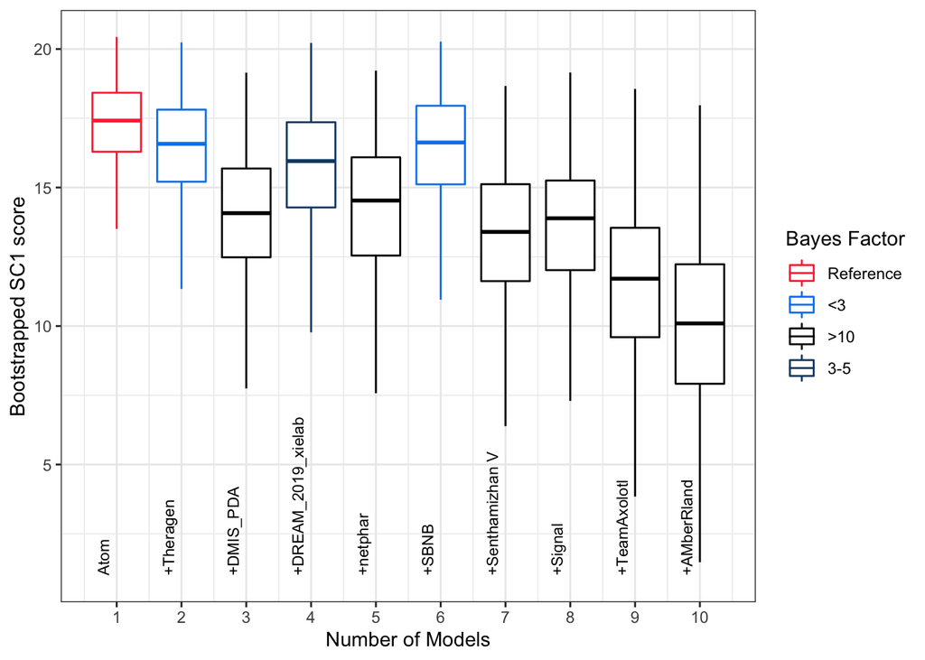

```r
ggplot(sc1_final, aes(x = number, y = -log2(bs_score), color = bayes_category, group = number)) +
    geom_boxplot(outlier.shape = NA) +
    theme_bw() +
  scale_color_manual(values = c("Reference"="#FB3640", '<3' = '#0585ED', "3-5" = "#124773",
                                "5-10" = '#183247', ">10" = "#000000"),
                      name = "Bayes Factor") +
  labs(y = 'Bootstrapped SC1 score', x = 'Number of Models') +
  annotate("text", x = 0.8, y = 1.0, label = "Atom", angle = 90,hjust = 0, size = 3) +
  annotate("text", x = 1.8, y = 1.0, label = "+Theragen", angle = 90,hjust = 0, size = 3) +
  annotate("text", x = 2.8, y = 1.0, label = "+DMIS_PDA", angle = 90,hjust = 0, size = 3) +
  annotate("text", x = 3.8, y = 1.0, label = "+DREAM_2019_xielab", angle = 90,hjust = 0, size = 3) +
  annotate("text", x = 4.8, y = 1.0, label = "+netphar",angle = 90,hjust = 0, size = 3) +
  annotate("text", x = 5.8, y = 1.0, label = "+SBNB",angle = 90,hjust = 0, size = 3)+
  annotate("text", x = 6.8, y = 1.0, label = "+Senthamizhan V",angle = 90,hjust = 0, size = 3)+
  annotate("text", x = 7.8, y = 1.0, label = "+Signal",angle = 90,hjust = 0, size = 3)+
  annotate("text", x = 8.8, y = 1.0, label = "+TeamAxolotl",angle = 90,hjust = 0, size = 3)+
  annotate("text", x = 9.8, y = 1.0, label = "+AMberRland",angle = 90,hjust = 0, size = 3)+
  scale_x_continuous(breaks= scales::pretty_breaks(10))
```

## SC2

Repeat, but for SC2, which is the significance of the target ranks as compared to a null model.

The ensemble method is a simple median ensemble. We take the top SC2 prediction file, and treat that as the reference (first “ensemble”). We then add the second, calculate the medians of the predictions, and treat that as the second ensemble. We then calculate the medians of the top 3, top 4, and so on, to create multiple ensemble predictions. Then, we bootstrap the median prediction files 1000 times, score them, and calculate Bayes factors to determine if any of aggregated predictions are better than the top single prediction file.

```r
query <- synTableQuery("SELECT * FROM syn22316156 where status = \'ACCEPTED\'")$filepath %>%
  read_csv() %>%
  filter(ROW_ID != 9696740, !is.na(writeUp))
```

```
##
 [####################]100.00%   1/1   Done...
Downloading  [####################]100.00%   2.4kB/2.4kB (562.0kB/s) 64122151.csv Done...
```

```r
query <- query %>%
  arrange(desc(sc2_score)) %>%
  mutate(rank = 1:nrow(.))

prediction_paths <- sapply(query$prediction_fileid, function(x){
  synGet(x)$path
})


query <- mutate(query, participant_name = sapply(submitterid, get_user_or_team_names)) %>%
      mutate(participant_name = case_when(participant_name == "Hyunmin Kim" ~ "Theragen",
                                participant_name != "Hyunmin Kim" ~ participant_name))

prediction_paths <- setNames(prediction_paths, query$participant_name)


gold_df <- gold %>%
    select(-cmpd) %>%
    group_by(cmpd_id) %>%
    nest() %>%
    arrange(cmpd_id)

 pred_df<- lapply(names(prediction_paths), function(x){
    read_csv(prediction_paths[[x]]) %>%
      gather(cmpd_id, confidence ,-target) %>%
      mutate(participant_name = x)
  }) %>% bind_rows() %>%
   left_join(query %>% select(participant_name, rank))

 median_preds_sc2 <- lapply(unique(pred_df$rank), function(i){
   colname <- paste0('median_ensemble_',i)
   foo <- pred_df %>%
     filter(rank <= i) %>%
     group_by(target, cmpd_id) %>%
     summarize(!!colname := median(confidence)) %>%
     ungroup()
   foo
 })

pred_df_combined<- lapply(median_preds_sc2, function(x){
    iter <- colnames(x)[3]
    x %>%
      rename(confidence = iter) %>%
      filter(target %in% targs) %>%
      group_by(cmpd_id) %>%
      arrange(-confidence, target) %>%
      nest() %>%
      arrange(cmpd_id) %>%
       rename({{iter}} := data)
  }) %>% reduce(left_join, by = 'cmpd_id')


sc2_vals <- sapply(1:1000, function(x){

    null_model <- template %>%
      gather(cmpd_id, confidence ,-target) %>%
      group_by(cmpd_id) %>%
      arrange(-confidence, target) %>%
      sample_frac(1, replace = F) %>%
      select(-confidence) %>%
      set_names(c('target', 'cmpd_id')) %>%
      filter(target %in% targs) %>%
      nest() %>%
      ungroup() %>%
      mutate(cmpd_id= 1:32) %>%
      rename(null = data)

    join <- inner_join(gold_df, pred_df_combined, by = 'cmpd_id') %>%
      ungroup() %>%
      sample_n(32, replace = T) %>%
      mutate(cmpd_id= 1:32) %>%
      inner_join(null_model, by = 'cmpd_id') %>%
      select(-cmpd_id)

    the_names <- colnames(join)

    join <- join %>%
      map(., function(a){
        map2(.$data, a, function(x,y){
          match(x$target, y$target) %>% unique()
        }) %>% unlist()
      }) %>% bind_rows


    colnames(join) <- the_names

    ps <- join %>%
      apply(., 2, function(x){
        wilcox.test(x = x, y= .$null, paired = T, exact = NULL)$p.value
      })


    if(any(is.nan(ps))){
      ps[is.nan(ps)] <- 1
    }
    ps

  }) %>% t()

sc2 <- sc2_vals %>%
  as_data_frame() %>%
  gather(model, bs_score) %>%
  filter(model != "data", model != "null") %>%
  mutate(number = stringr::str_extract(model, '[0-9]+') %>% as.numeric())

 sc2_bf <- challengescoring::computeBayesFactor(bootstrapMetricMatrix = sc2_vals, refPredIndex = 2, invertBayes = F) %>%
    as_tibble(rownames = "model") %>%
    rename(bayes = value)
```

Then plot SC2 results. Red indicates the reference model, light blue indicates a Bayes factor of <3 (statistically indistinguishable), while darker colors indicates a larger Bayes factor. The second model (a combination of the top two) is marginally better but statistically indistinguishable from the reference. Subsequent models are substantially less performant, with the exception of the combination of the top 4 and top 6 models, which are again statistically indistinguishable from the reference.

```r
sc2_bf %>% filter(!model %in% c('data','null')) %>% arrange(bayes)
```

| model | bayes |
| --- | --- |
| median_ensemble_1 | 0.0000000 |
| median_ensemble_2 | 0.4044944 |
| median_ensemble_4 | 1.7855153 |
| median_ensemble_6 | 1.9761905 |
| median_ensemble_5 | 4.7803468 |
| median_ensemble_8 | 4.9880240 |
| median_ensemble_9 | 6.9365079 |
| median_ensemble_3 | 8.1743119 |
| median_ensemble_7 | 11.9870130 |
| median_ensemble_10 | 20.2765957 |

```r
sc2_final <- sc2 %>%
  filter(!model %in% c('data','null')) %>%
  left_join(sc2_bf) %>%
  mutate(bayes_category = case_when(bayes == 0 ~ 'Reference',
                                    bayes<=3 ~ '<3',
                                    bayes>=3 & bayes <5 ~ "3-5",
                                    bayes>=5 & bayes <10 ~ "5-10",
                                    bayes>=10 ~ ">10"))


ensemble_inclusions <- pred_df %>%
  select(participant_name, rank) %>%
  distinct

ensemble_inclusions
```

| participant_name | rank |
| --- | --- |
| netphar | 1 |
| SBNB | 2 |
| DREAM_2019_xielab | 3 |
| Atom | 4 |
| DMIS_PDA | 5 |
| Theragen | 6 |
| Signal | 7 |
| AMbeRland | 8 |
| TeamAxolotl | 9 |
| Senthamizhan V | 10 |

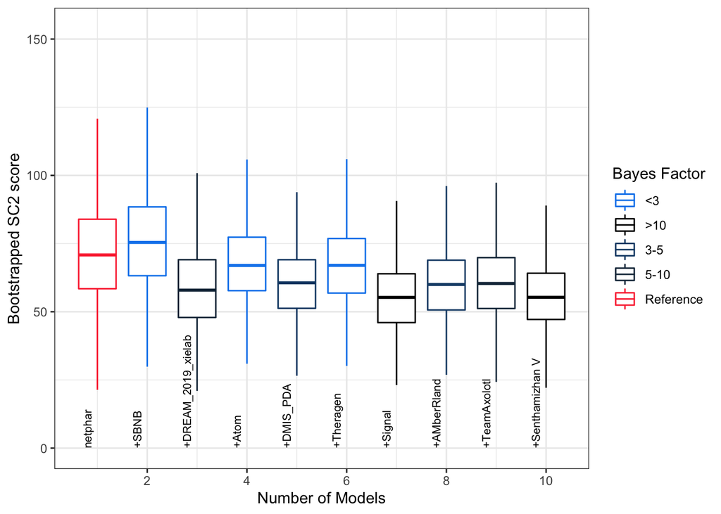

```r
ggplot(sc2_final, aes(x = number, y = -log2(bs_score), color = bayes_category, group = number)) +
    geom_boxplot(outlier.shape = NA) +
    theme_bw() +
  scale_color_manual(values = c("Reference"="#FB3640", '<3' = '#0585ED', "3-5" = "#124773",
                                "5-10" = '#183247', ">10" = "#000000"),
                      name = "Bayes Factor") +
  labs(y = 'Bootstrapped SC2 score', x = 'Number of Models') +
  annotate("text", x = 0.8,  y = 0, label = "netphar", angle = 90,hjust = 0, size = 2.8) +
  annotate("text", x = 1.8,  y = 0, label = "+SBNB", angle = 90,hjust = 0, size = 2.8) +
  annotate("text", x = 2.8,  y = 0, label = "+DREAM_2019_xielab", angle = 90,hjust = 0, size = 2.75) +
  annotate("text", x = 3.8,  y = 0, label = "+Atom", angle = 90,hjust = 0, size = 2.8) +
  annotate("text", x = 4.8,  y = 0, label = "+DMIS_PDA",angle = 90,hjust = 0, size = 2.8) +
  annotate("text", x = 5.8,  y = 0, label = "+Theragen",angle = 90,hjust = 0, size = 2.8)+
  annotate("text", x = 6.8,  y = 0, label = "+Signal",angle = 90,hjust = 0, size = 2.8)+
  annotate("text", x = 7.8,  y = 0, label = "+AMberRland",angle = 90,hjust = 0, size = 2.8)+
  annotate("text", x = 8.8,  y = 0, label = "+TeamAxolotl",angle = 90,hjust = 0, size = 2.8)+
  annotate("text", x = 9.8,  y = 0, label = "+Senthamizhan V",angle = 90,hjust = 0, size = 2.8)+
  scale_x_continuous(breaks= scales::pretty_breaks())
```